# Bayesian DiD — Maintenance LLM Tool ROI

Brolin O’Connell

2026-02-27

## What Is a Cost Overrun?

A **cost overrun** is the amount by which a job’s final cost exceeds its original estimate. If a work order is estimated at $10,000 and comes in at $11,800, that is an 18% overrun (ratio = 1.18). Overruns happen for normal reasons — unexpected site conditions, scope changes, parts delays, vendor repricing — but they compound across hundreds of work orders per year. Even a modest systematic reduction in overrun rates recovers real budget.

This analysis asks: **did facilities using the LLM tool experience lower overruns than comparable facilities without it, after controlling for time trends?**

## The Model

We estimate the causal effect using Bayesian difference-in-differences:

$$y_i = \alpha + \beta_1 \, \text{Treated}_i + \beta_2 \, \text{Post}_i +
\beta_3 (\text{Treated}_i \times \text{Post}_i) + \epsilon_i$$

- $y_i = \log(\text{final cost}_i \;/\; \text{estimated cost}_i)$ — the log overrun ratio.
- $\beta_1$ captures pre-existing differences between treated and control sites.
- $\beta_2$ captures the time trend (changes affecting everyone after March).
- $\beta_3$ is the **ATT** (average treatment effect on the treated) — the causal change in overrun attributable to the tool.
- Because the outcome is log-transformed: $\%\;\text{change} = e^{\hat\beta_3} - 1$.

Priors are weakly informative and skeptical of large effects:

$$\beta_k \sim \mathcal{N}(0,\; 0.5^2), \qquad \sigma \sim
\text{Exponential}(2)$$

Every posterior draw of $\beta_3$ passes through the ROI formula, producing a distribution over ROI rather than a single number:

$$\text{ROI}^{(s)} = \frac{|e^{\beta_3^{(s)}} - 1| \cdot \bar{C} \cdot N
\;-\; \text{Cost}_{\text{tool}}}{\text{Cost}_{\text{tool}}}, \quad s =
1,\dots,S$$

## Treatment Effect

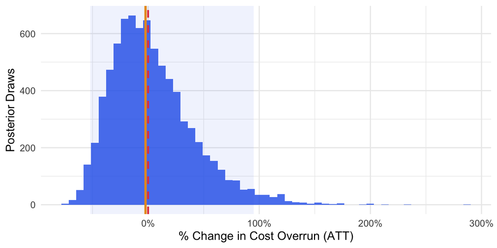

Median ATT: **-2.3%** · 95% CI: [-52.1%, 95%] · P(effect < 0): **52.8%**

## ROI

| Metric | Value | 95% CI |
| --- | --- | --- |
| Gross Savings (overrun reduction) | $322,353 | $14,650 – $1,314,121 |
| Tool Cost (license + setup + training + API) | $160,000 | — |
| Net Savings | $162,353 | -$145,350 – $1,154,121 |
| ROI % | 101% | -91% – 721% |
| P(ROI > 0) | 74% | — |

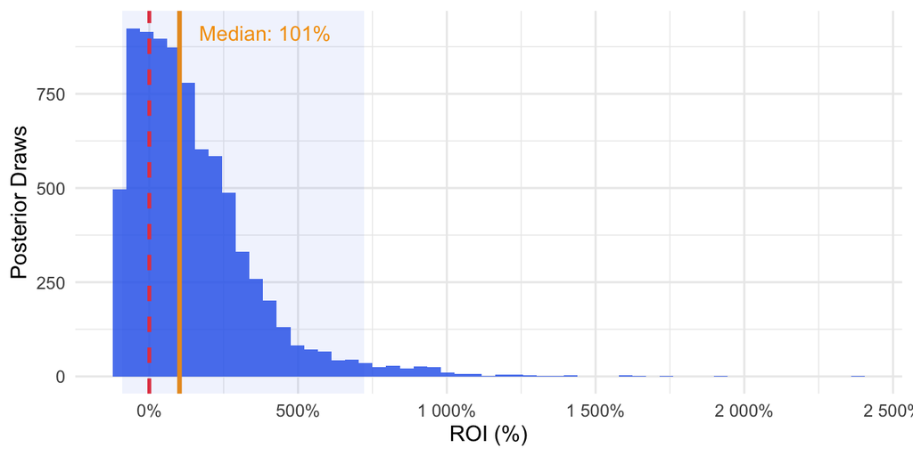